# 8e: ARMA-GARCH

[Nao Mimoto](https://nmimoto.github.io/) - [Dept. of Statistics](http://www.uakron.edu/stat/) : [The University of Akron](http://www.uakron.edu) [– Class Web Page](https://nmimoto.github.io/477/)

## 1. ARMA-GARCH model

Let $Y_t$ be the observatoin. (Log-difference of the financial time series) Then,
$$\begin{align*}
Y_t & \sim \mbox{ARMA}(p,q)\\\\
Y_t &= \phi_1 Y_{t-1} + \epsilon_t + \theta_1 \epsilon_{t-1}
\end{align*}$$
with GARCH error
$$\begin{align*}
\epsilon_t &= \hspace{3mm} \sigma_t \epsilon_t \hspace{5mm}
\epsilon_t \sim N(0,1)\\\\
\sigma_t^2 \hspace{3mm} = \hspace{3mm} \omega + \alpha Y_t^2 + \beta
\sigma_t^2
\end{align*}$$

$Y_t$ is ARMA with error $\epsilon_t$. $\epsilon_t$ is GARCH.
$$\begin{align*}
\Phi(B) Y_t &= \Theta(B) \epsilon_t \\ \\
\epsilon_t &= \sigma_t \epsilon_t \hspace{10mm} \epsilon_t
\sim_{iid} N(0,1) \\\\
\sigma_t^2 &= \omega + \alpha \epsilon_{t-1}^2 + \beta
\sigma^2_{t-1}
\end{align*}$$

## 2. Example: SPY

```r
  library(quantmod)
  source('https://nmimoto.github.io/R/TS-00.txt')


  getSymbols("SPY")    #- SP500 download from Yahoo!
```

```
## [1] "SPY"
```

```r
  SPY = Ad(SPY)['2010::']

  is.ts(SPY)      # not ts object
```

```
## [1] FALSE
```

```r
  is.xts(SPY)     # its xts object
```

```
## [1] TRUE
```

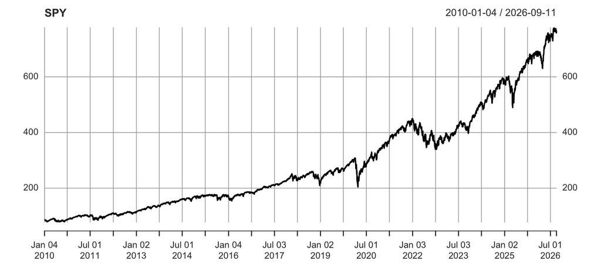

```r
  plot( SPY )
```

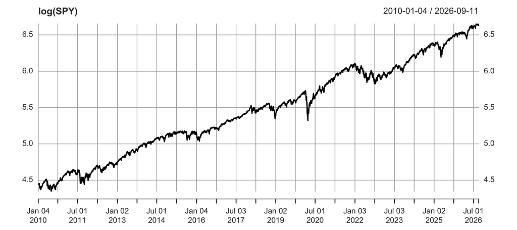

```r
  plot( log(SPY) )
```

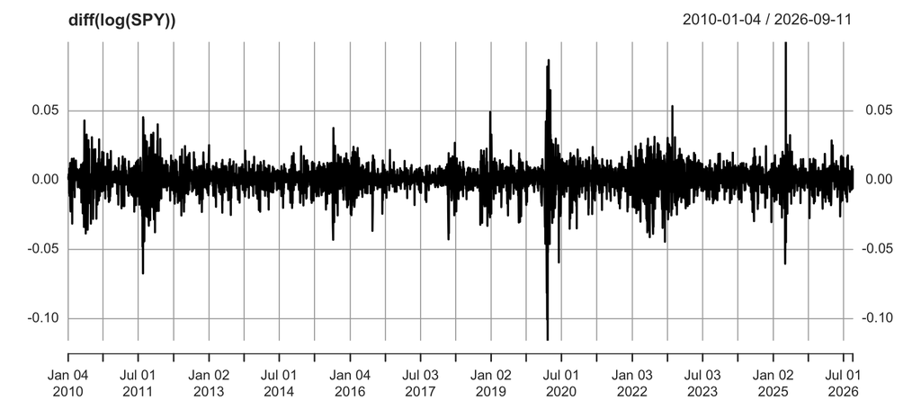

```r
  plot( diff( log(SPY) ) )
```

### 2a. Fit ARMA-GARCH

```r
  library(fGarch)

  Y = diff( log(SPY) )[-1]     # remove the first diff for NA

  #- Estimae parameters of ARMA and GARCH at the same time
  Fit01 =  garchFit(~ arma(5,5) + garch(1,1), data=Y, cond.dist="norm",  include.mean = FALSE, trace = FALSE)
  summary(Fit01)
```

```
##
## Title:
##  GARCH Modelling
##
## Call:
##  garchFit(formula = ~arma(5, 5) + garch(1, 1), data = Y, cond.dist = "norm",
##     include.mean = FALSE, trace = FALSE)
##
## Mean and Variance Equation:
##  data ~ arma(5, 5) + garch(1, 1)
## <environment: 0x160dc3d58>
##  [data = Y]
##
## Conditional Distribution:
##  norm
##
## Coefficient(s):
##         ar1          ar2          ar3          ar4          ar5          ma1
## -7.4255e-01  -1.5549e-01  -8.7181e-01  -5.6246e-01   3.7109e-01   7.1967e-01
##         ma2          ma3          ma4          ma5        omega       alpha1
##  1.3684e-01   8.6172e-01   5.3251e-01  -3.9581e-01   3.7362e-06   1.4904e-01
##       beta1
##  8.1578e-01
##
## Std. Errors:
##  based on Hessian
##
## Error Analysis:
##          Estimate  Std. Error  t value Pr(>|t|)
## ar1    -7.425e-01         NaN      NaN      NaN
## ar2    -1.555e-01         NaN      NaN      NaN
## ar3    -8.718e-01         NaN      NaN      NaN
## ar4    -5.625e-01         NaN      NaN      NaN
## ar5     3.711e-01         NaN      NaN      NaN
## ma1     7.197e-01         NaN      NaN      NaN
## ma2     1.368e-01         NaN      NaN      NaN
## ma3     8.617e-01         NaN      NaN      NaN
## ma4     5.325e-01         NaN      NaN      NaN
## ma5    -3.958e-01         NaN      NaN      NaN
## omega   3.736e-06   4.809e-07    7.769 7.99e-15 ***
```

[output cut: 13 more lines]

```
## Standardised Residuals Tests:
##                                   Statistic   p-Value
##  Jarque-Bera Test   R    Chi^2  1015.142128 0.0000000
##  Shapiro-Wilk Test  R    W         0.972619 0.0000000
##  Ljung-Box Test     R    Q(10)     7.188338 0.7075531
##  Ljung-Box Test     R    Q(15)    11.849116 0.6904120
##  Ljung-Box Test     R    Q(20)    18.354837 0.5640458
##  Ljung-Box Test     R^2  Q(10)    13.867852 0.1791051
##  Ljung-Box Test     R^2  Q(15)    16.191197 0.3694597
##  Ljung-Box Test     R^2  Q(20)    16.790092 0.6665588
##  LM Arch Test       R    TR^2     15.163040 0.2326412
##
## Information Criterion Statistics:
##       AIC       BIC       SIC      HQIC
## -6.630260 -6.610615 -6.630279 -6.623313
```

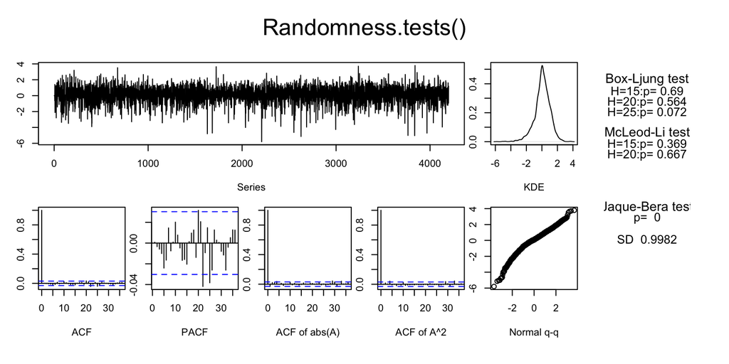

```
##   B-L test H0: the series is uncorrelated
##   M-L test H0: the square of the series is uncorrelated
##   J-B test H0: the series came from Normal distribution
##   SD         : Standard Deviation of the series
```

```
##      BL15  BL20  BL25  ML15  ML20 JB    SD
## [1,] 0.69 0.564 0.072 0.369 0.667  0 0.998
```

```r
  sig.t  = xts(Fit01@sigma.t,                 order.by=index(Y))
                               #-- estimated sig_t fo GARCH
  res01  = xts(Fit01@residuals/Fit01@sigma.t, order.by=index(Y))
                               #-- this is the (standardized) ARMA-GARCH residuals

  Randomness.tests(res01)
```

```r
  ##plot(Fit1)            #-- choose option 13 for residual qq plot

    ##  Fit01@fit$par                  # estimated parameters
    ##  Fit01@residuals                # this is not GARCH residuals! This is same as Y.
    ##  Fit01@sigma.t                  # estimated sig_t
    ##  Fit01@fit$ics                   # AIC and BIC are here
    ##  Fit01@residuals/Fit1@sigma.t   # this is the (standardized) GARCH residuals

  #- Estimae parameters of ARMA and GARCH at the same time
  Fit02 =  garchFit(~ garch(1,1), data=Y, cond.dist="norm",  include.mean = FALSE, trace = FALSE)
  summary(Fit02)
```

```
##
## Title:
##  GARCH Modelling
##
## Call:
##  garchFit(formula = ~garch(1, 1), data = Y, cond.dist = "norm",
##     include.mean = FALSE, trace = FALSE)
##
## Mean and Variance Equation:
##  data ~ garch(1, 1)
## <environment: 0x13c81c9b0>
##  [data = Y]
##
## Conditional Distribution:
##  norm
##
## Coefficient(s):
##      omega      alpha1       beta1
## 3.7798e-06  1.5098e-01  8.1387e-01
##
## Std. Errors:
##  based on Hessian
##
## Error Analysis:
##         Estimate  Std. Error  t value Pr(>|t|)
## omega  3.780e-06   4.755e-07    7.949 1.78e-15 ***
## alpha1 1.510e-01   1.290e-02   11.703  < 2e-16 ***
## beta1  8.139e-01   1.396e-02   58.291  < 2e-16 ***
## ---
## Signif. codes:  0 '***' 0.001 '**' 0.01 '*' 0.05 '.' 0.1 ' ' 1
##
## Log Likelihood:
##  13917.88    normalized:  3.316149
##
## Description:
##  Sun Sep 13 15:24:57 2026 by user:
##
##
##
## Standardised Residuals Tests:
##                                    Statistic   p-Value
##  Jarque-Bera Test   R    Chi^2  1020.8847125 0.0000000
##  Shapiro-Wilk Test  R    W         0.9727087 0.0000000
##  Ljung-Box Test     R    Q(10)    10.3053323 0.4141262
##  Ljung-Box Test     R    Q(15)    16.2668287 0.3645432
##  Ljung-Box Test     R    Q(20)    24.4955019 0.2214173
##  Ljung-Box Test     R^2  Q(10)    13.9808894 0.1738651
##  Ljung-Box Test     R^2  Q(15)    16.1999190 0.3688908
##  Ljung-Box Test     R^2  Q(20)    16.8389205 0.6634071
##  LM Arch Test       R    TR^2     14.8604609 0.2491563
##
## Information Criterion Statistics:
##       AIC       BIC       SIC      HQIC
## -6.630869 -6.626336 -6.630870 -6.629266
```

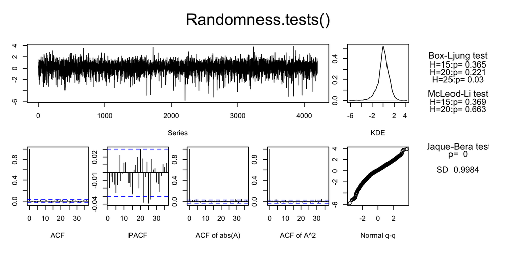

```
##   B-L test H0: the series is uncorrelated
##   M-L test H0: the square of the series is uncorrelated
##   J-B test H0: the series came from Normal distribution
##   SD         : Standard Deviation of the series
```

```
##       BL15  BL20 BL25  ML15  ML20 JB    SD
## [1,] 0.365 0.221 0.03 0.369 0.663  0 0.998
```

```r
  res02 = Y/Fit02@sigma.t
  Randomness.tests(res02)
```

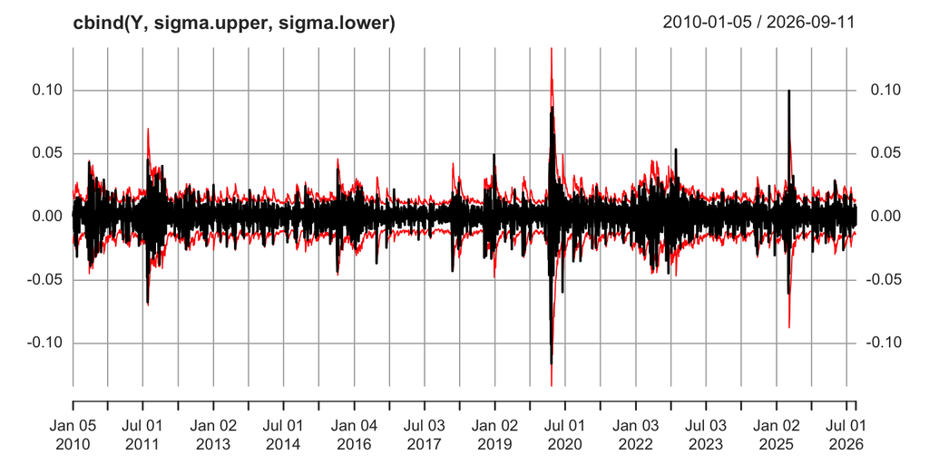

```r
  #- plot log-return and sigma_t -
    sigma.upper = xts(1.96*Fit01@sigma.t,  order.by=index(Y))
    sigma.lower = xts(-1.96*Fit01@sigma.t, order.by=index(Y))

    plot( cbind(Y, sigma.upper, sigma.lower),
        col=c("black", "red", "red"), lwd=c(2,1,1) )
```

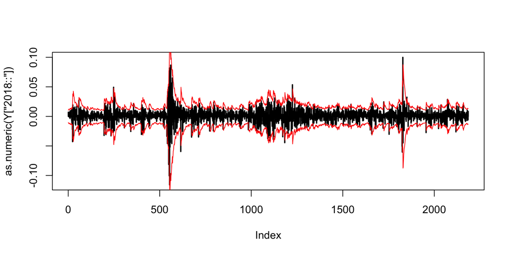

```r
    plot(  as.numeric(          Y["2018::"]), type="h", lwd=2)
    lines( as.numeric(sigma.upper["2018::"]), col="red")
    lines( as.numeric(sigma.lower["2018::"]), col="red")
```

```r
  # h-step ahead prediction from ARMA-GARCH
  h = 15    #- predict 15 days ahead

  X.pred  = xts(predict(Fit2, n.ahead=h)[,1], order.by=index(X1)[length(X1)]+(1:h))
  SD.pred = xts(predict(Fit2, n.ahead=h)[,3], order.by=index(X1)[length(X1)]+(1:h))

  # plot log-return overlay with sigma_t
  plot(rbind(X1["2014"], X.pred))
  lines(X.pred, col="red")
  lines( 1.96*SD.pred, type="l", col="red")
  lines(-1.96*SD.pred, type="l", col="red")
```

[output not shown]

```r
  # Rolling 1-step prediction of sig.t and ARMA
  Y = diff( log(SPY["2013::"]) )[-1]    # Original data
  window.size = 250                         # Window size for estimation

    Y.pred1   = numeric(0)
    sig.pred1 = numeric(0)
    date.stp  = numeric(0)
    for (i in 1:(length(Y)-window.size)){
      T = Y[(1:window.size)+(i-1)]
      n = length(T)
      out1  =  garchFit(~ arma(0,3) + garch(1,1), data=T, cond.dist="norm", include.mean = FALSE, trace = FALSE)
      Y.pred1[i]   = predict(out1)[1,1]   #  ARMA prediction
      sig.pred1[i] = predict(out1)[1,3]   #  sig.t prediction
      date.stp[i]  = index(Y)[window.size+i]
    }
```

[output not shown]

[output cut: 64 more lines]

[output not shown]

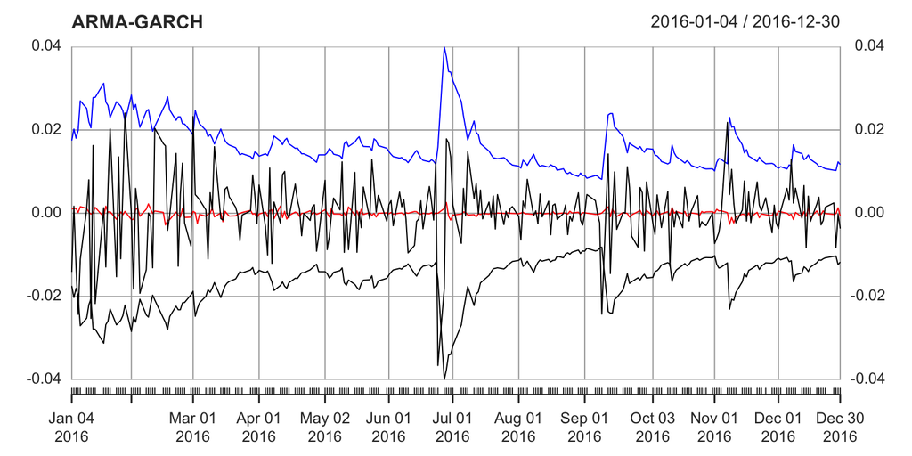

```r
    Y.pred   = xts(Y.pred1,   order.by=as.Date(date.stp))
    sig.pred = xts(sig.pred1, order.by=as.Date(date.stp))

  # Plot and compare estimated vs rolling predicted
  plot(cbind(Y[             '2016'],
             Y.pred[        '2016'],
             1.96*sig.pred[ '2016'],
            -1.96*sig.pred[ '2016']),
     col=c("black", "red", "blue"), lwd=c(1,1,1),
     main="ARMA-GARCH")
```

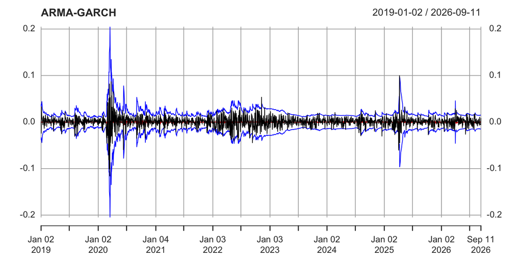

```r
  time.period="2019::"
    plot(cbind(Y[          time.period],
               Y.pred[     time.period],
             1.96*sig.pred[time.period],
            -1.96*sig.pred[time.period]),
     col=c("black", "red", "blue", "blue"), lwd=c(1,1,1),
     main="ARMA-GARCH")
```

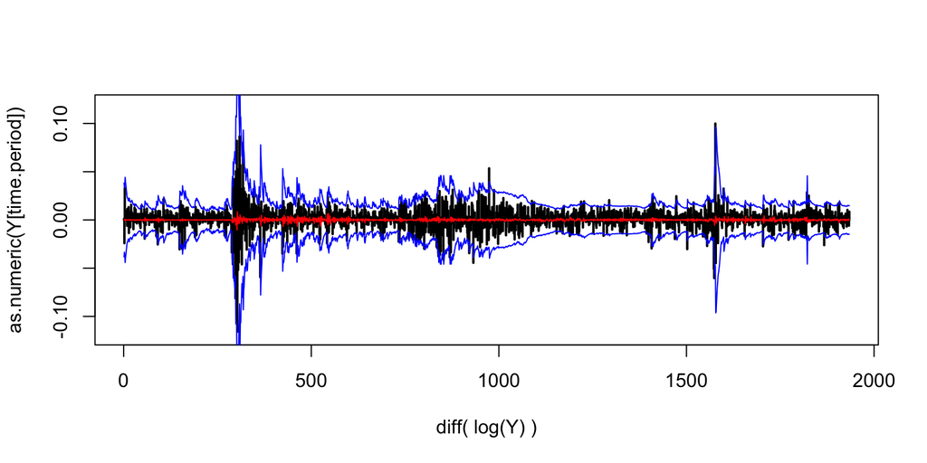

```r
  time.period="2019::"
    plot(  as.numeric(             Y[time.period]), type="h", lwd=2, ylim=c(-.12, .12),
            xlab="diff( log(Y) )")
    lines( as.numeric(        Y.pred[time.period]), col="red")
    lines( as.numeric( 1.96*sig.pred[time.period]), col="blue")
    lines( as.numeric(-1.96*sig.pred[time.period]), col="blue")
```

```r
  mean( sign(Y[index(Y.pred)])==sign(Y.pred) )  #- Can Y.pred guess up/down ?
```

```
## [1] 0.4901347
```

```r
  mean( sign(Y[index(Y.pred)])==1 )             #- num of days SPY went up
```

```
## [1] 0.5502662
```

[output not shown]

[output not shown]

[output not shown]

## 3. Cheking Conditional Distribution

### 3a. Empirical Distribution Function

Sample version of CDF
$$\hat F_n(x) \hspace{3mm} = \hspace{3mm} \frac{1}{n} \sum_{i=1}^n
I(x_i < x)$$

```r
  X22 = rnorm(10)
  X22
```

```
##  [1] -2.1015322  0.8825195 -1.2327865  1.5668140  0.5881110  1.0515181
##  [7] -0.7412360 -1.1190486 -0.1183287 -0.3939993
```

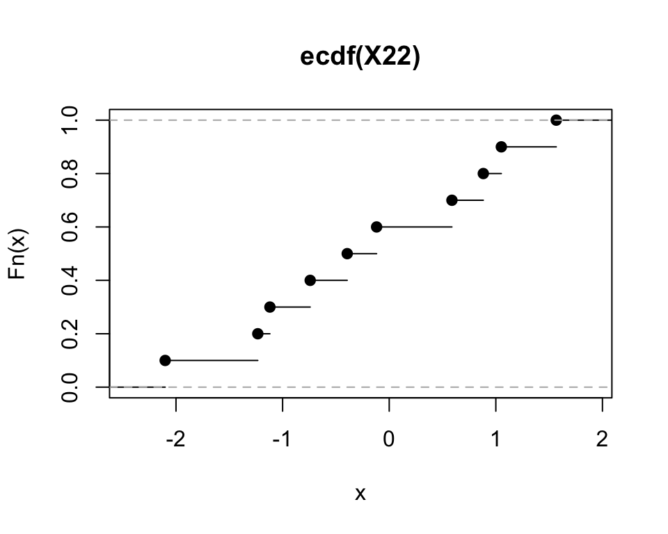

```r
  plot(ecdf(X22))
```

### 3b. Kolmogolov-Smirnov Test

In iid setting, K-S test can be used to test hypothesis $X_i \sim F$, and

$$H_0: F = F_0 \hspace{5mm} vs \hspace{5mm} H_A: F \ne
F_0 \hspace{10mm} \mbox{{\scriptsize ($F_0$ is completely specified) }
}$$

K-S test uses Empirical Distibution (EDF, ECDF), and calculate the test statistic
$$KS \hspace{3mm} = \hspace{3mm} \sup_x |\hat F_n(x) - F(x) |$$

Where is $(\frac{i}{n}, X_{(i)})$ and $(\frac{i-1}{n}, X_{(i)})$?
$$\begin{align*}
D_n &= \sup_x |\hat F_n(x) - F_0(x)| \\\\
&= \max_i \Big( \Big|\frac{i}{n} - F_0(x_{(i)}) \Big| ,
\hspace{3mm}
\Big|\frac{i-1}{n} - F_0(x_{(i)}) \Big| \Big) \\ \\
\end{align*}$$

If $X_i$ are indeed from $F_0$,
$$D_n \hspace{3mm} =_d \hspace{3mm}
\max_i \Big( \Big|\frac{i}{n} - U_{(i)} \Big| , \hspace{3mm}
\Big|\frac{i-1}{n} - U_{(i)} \Big| \Big)$$
with $U_i \sim_{iid} Unif(0,1)$.

No matter what $F$ is, distribution of the test statistic KS under the null is known.

KS test with completely specified $F_0$ is a distribution-free test.

When $F_0$ contains nuisance parameter, Distribution of $D_n$ under the null depends on $F$. KS test becomes only asymptotically distribution free test. For finite $n$, null distribution must be computed by Monte Carlo simulation.

### 3c. K-S test in Time Series Setting

In time sries, we want to use K-S test for checking distribution of innovations. (errors).

Since we assume $\epsilon_t$ are i.i.d. noise, if we can observe $\epsilon_t$, K-S test can be directly applicable.

However, in Time Series analysis $\epsilon_t$ are not observable, and only residuals $\hat \epsilon_t$ are available.

Can we still use K-S test on $\hat \epsilon_t$?

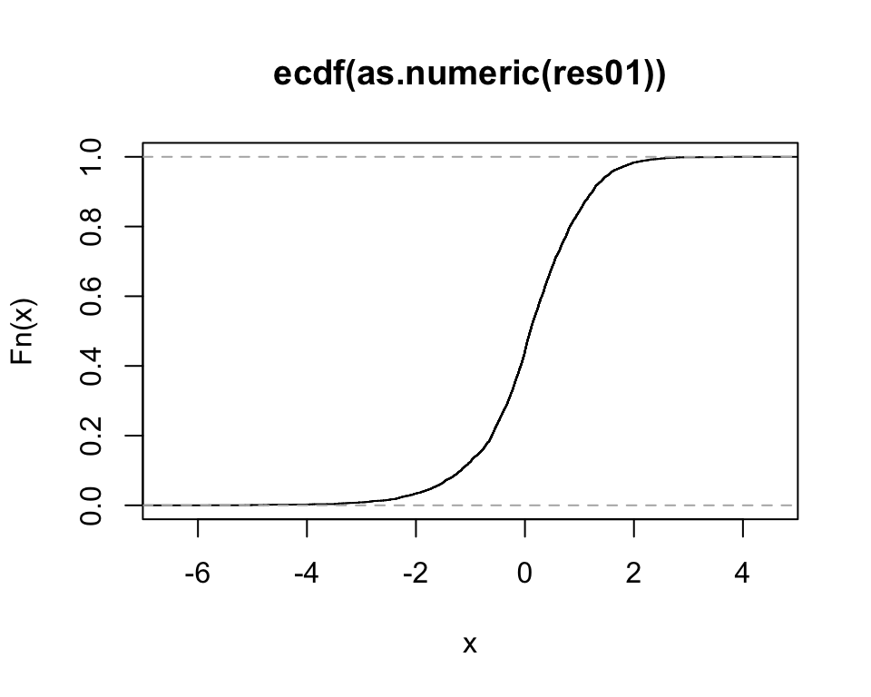

```r
  Fn = ecdf(as.numeric(res01))   #- Fn becomes an function
  plot( ecdf(as.numeric(res01)) )
```

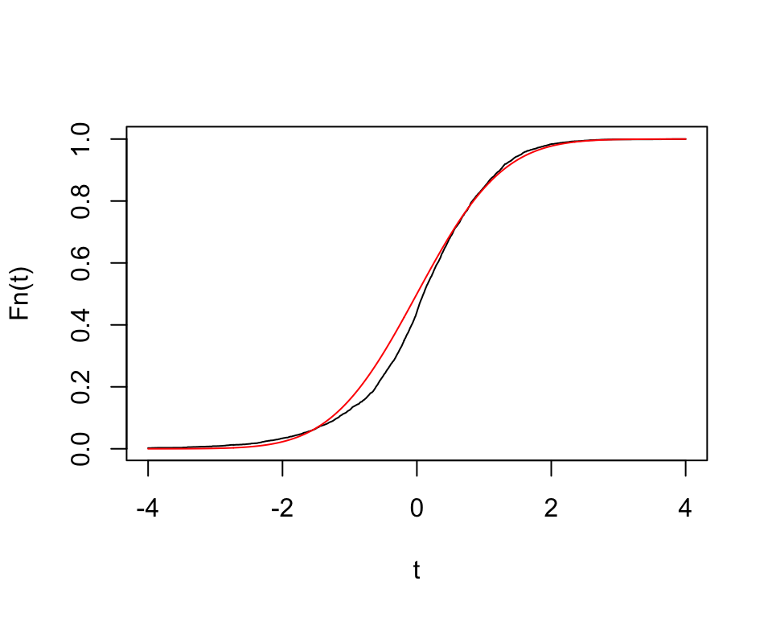

```r
  t=seq(-4,4, .01)
  plot(t,  Fn(t), type="l" )
  lines(t, pnorm(t,0,1), col="red")
```

```r
  ks.test(as.numeric(res01), "pnorm")
```

```
##
##  Asymptotic one-sample Kolmogorov-Smirnov test
##
## data:  as.numeric(res01)
## D = 0.081575, p-value < 2.2e-16
## alternative hypothesis: two-sided
```